# Figure S9: DNA-PAINT validation and quantification

# Fig S9A

Cumulative detected MIC60 copies over DNA-PAINT acquisition frames.

**Source data**  
`Fig S9A, B.csv`

**Columns**

- `Date` — Experiment date
- `Condition` — Control or TTX
- `Dish` — Culture dish ID
- `Cell` — Cell ID
- `frame_bin` — Acquisition frame range
- `Mic60` — MIC60 copies detected in the frame bin

## Data

Copy counts are accumulated across frames within each cell.

```r
suppressPackageStartupMessages({
  library(dplyr); library(readr); library(tidyr); library(ggplot2)
})

mic60_df <- read_csv("./Fig S9A, B.csv", show_col_types = FALSE) %>%
  select(Date, Condition, Dish, Cell, frame_bin, Mic60) %>%
  mutate(Condition = trimws(as.character(Condition)),
         frame_bin = trimws(as.character(frame_bin)),
         Mic60 = as.numeric(Mic60)) %>%
  filter(Condition %in% c("Control", "TTX"), is.finite(Mic60)) %>%
  extract(frame_bin, c("bin_start", "bin_end"), "^(\\d+)\\s*-\\s*(\\d+)$",
          remove = FALSE, convert = TRUE)

if (any(is.na(mic60_df$bin_start) | is.na(mic60_df$bin_end)))
  stop("One or more frame_bin values could not be parsed.")
if (any(count(mic60_df, Date, Condition, Dish, Cell, frame_bin)$n > 1))
  stop("Duplicate rows were found for the same trace and frame bin.")

mic60_df <- mic60_df %>%
  mutate(Condition = factor(Condition, levels = c("Control", "TTX"))) %>%
  group_by(Date, Condition, Dish, Cell) %>%
  arrange(bin_start, .by_group = TRUE) %>%
  mutate(Mic60_cumulative = cumsum(Mic60)) %>%
  ungroup()

mic60_df %>% select(Date, Condition, Dish, Cell, frame_bin, Mic60) %>%
  mutate(Mic60 = round(Mic60, 3))
```

| Date | Condition | Dish | Cell | frame_bin | Mic60 |
| --- | --- | --- | --- | --- | --- |
| 2026-01-08 | Control | 1 | 1 | 0-1200 | 0 |
| 2026-01-08 | Control | 1 | 1 | 1200-2400 | 0 |
| 2026-01-08 | Control | 1 | 1 | 2400-3600 | 0 |
| 2026-01-08 | Control | 1 | 1 | 3600-4800 | 0 |
| 2026-01-08 | Control | 1 | 1 | 4800-6000 | 0 |
| 2026-01-08 | Control | 1 | 1 | 6000-7200 | 0 |
| 2026-01-08 | Control | 1 | 1 | 7200-8400 | 0 |
| 2026-01-08 | Control | 1 | 1 | 8400-9600 | 0 |
| 2026-01-08 | Control | 1 | 1 | 9600-10800 | 0 |
| 2026-01-08 | Control | 1 | 1 | 10800-12000 | 0 |

[output cut: 2240 more lines]

## Summary

```r
summary_table <- mic60_df %>%
  distinct(Date, Condition, Dish, Cell) %>%
  group_by(Condition) %>%
  summarise(n_Traces = n(), n_Experiment_Dates = n_distinct(Date), .groups = "drop")

mic60_summary <- mic60_df %>%
  group_by(Condition, frame_bin, bin_start, bin_end) %>%
  summarise(mean = mean(Mic60_cumulative),
            SEM = sd(Mic60_cumulative) / sqrt(n()),
            n = n(), .groups = "drop") %>%
  mutate(SEM = if_else(n > 1, SEM, 0), Frames = bin_end) %>%
  arrange(Condition, bin_start)

summary_table
```

| Condition | n_Traces | n_Experiment_Dates |
| --- | --- | --- |
| Control | 23 | 3 |
| TTX | 22 | 3 |

```r
mic60_summary %>% select(Condition, Frames, mean, SEM) %>%
  mutate(across(c(mean, SEM), ~ round(.x, 3)))
```

| Condition | Frames | mean | SEM |
| --- | --- | --- | --- |
| Control | 1200 | 0.000 | 0.000 |
| Control | 2400 | 0.000 | 0.000 |
| Control | 3600 | 0.000 | 0.000 |
| Control | 4800 | 0.000 | 0.000 |
| Control | 6000 | 0.000 | 0.000 |
| Control | 7200 | 0.000 | 0.000 |
| Control | 8400 | 0.000 | 0.000 |
| Control | 9600 | 0.000 | 0.000 |
| Control | 10800 | 0.000 | 0.000 |
| Control | 12000 | 0.000 | 0.000 |

[output cut: 90 more lines]

## Statistics

Descriptive analysis.

## Plot

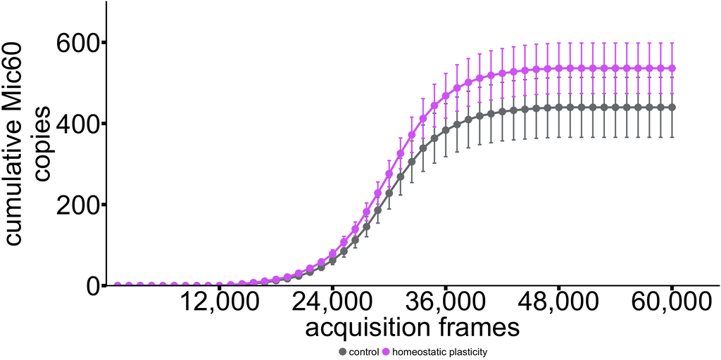

```r
set.seed(20261109)
figs9a_plot <- ggplot(mic60_summary, aes(Frames, mean, color = Condition, group = Condition)) +
  geom_errorbar(aes(ymin = mean - SEM, ymax = mean + SEM), width = 400, linewidth = 2) +
  geom_line(linewidth = 3) +
  geom_point(size = 10) +
  scale_color_manual(labels=c(Control="control",TTX="homeostatic plasticity"), values = c(Control = "#777B7E", TTX = "#D871F5")) +
  scale_x_continuous(oob = scales::oob_keep, breaks = c(12000, 24000, 36000, 48000, 60000),
                     labels = scales::label_comma(),
                     limits = c(0, 65000), expand = c(0, 0)) +
  scale_y_continuous(oob = scales::oob_keep, breaks = c(0, 200, 400, 600),
                     limits = c(0, 700), expand = c(0, 0),
                     labels = scales::label_comma()) +
  labs(x = "acquisition frames", y = "cumulative Mic60\ncopies") +
  theme_classic() +
  theme(axis.title = element_text(size = 80, color = "black"),
        axis.text = element_text(size = 80, color = "black"),
        axis.ticks = element_line(linewidth = 5, color = "black"),
        axis.ticks.length = grid::unit(0.5, "cm"),
        axis.line = element_line(linewidth = 2, color = "black"),
        legend.position = "bottom", legend.text = element_text(size=30), legend.title = element_blank())
figs9a_plot
```

# Fig S9B

Cumulative detected ATP synthase copies over DNA-PAINT acquisition frames.

**Source data**  
`Fig S9A, B.csv`

**Columns**

- `Date` — Experiment date
- `Condition` — Control or TTX
- `Dish` — Culture dish ID
- `Cell` — Cell ID
- `frame_bin` — Acquisition frame range
- `ATP_synthase` — ATP synthase copies detected in the frame bin

## Data

Copy counts are accumulated across frames within each cell.

```r
suppressPackageStartupMessages({
  library(dplyr); library(readr); library(tidyr); library(ggplot2)
})

atp_df <- read_csv("./Fig S9A, B.csv", show_col_types = FALSE) %>%
  select(Date, Condition, Dish, Cell, frame_bin, ATP_synthase) %>%
  mutate(Condition = trimws(as.character(Condition)),
         frame_bin = trimws(as.character(frame_bin)),
         ATP_synthase = as.numeric(ATP_synthase)) %>%
  filter(Condition %in% c("Control", "TTX"), is.finite(ATP_synthase)) %>%
  extract(frame_bin, c("bin_start", "bin_end"), "^(\\d+)\\s*-\\s*(\\d+)$",
          remove = FALSE, convert = TRUE)

if (any(is.na(atp_df$bin_start) | is.na(atp_df$bin_end)))
  stop("One or more frame_bin values could not be parsed.")
if (any(count(atp_df, Date, Condition, Dish, Cell, frame_bin)$n > 1))
  stop("Duplicate rows were found for the same trace and frame bin.")

atp_df <- atp_df %>%
  mutate(Condition = factor(Condition, levels = c("Control", "TTX"))) %>%
  group_by(Date, Condition, Dish, Cell) %>%
  arrange(bin_start, .by_group = TRUE) %>%
  mutate(ATP_synthase_cumulative = cumsum(ATP_synthase)) %>%
  ungroup()

atp_df %>% select(Date, Condition, Dish, Cell, frame_bin, ATP_synthase) %>%
  mutate(ATP_synthase = round(ATP_synthase, 3))
```

| Date | Condition | Dish | Cell | frame_bin | ATP_synthase |
| --- | --- | --- | --- | --- | --- |
| 2026-01-08 | Control | 1 | 1 | 0-1200 | 0 |
| 2026-01-08 | Control | 1 | 1 | 1200-2400 | 0 |
| 2026-01-08 | Control | 1 | 1 | 2400-3600 | 0 |
| 2026-01-08 | Control | 1 | 1 | 3600-4800 | 0 |
| 2026-01-08 | Control | 1 | 1 | 4800-6000 | 0 |
| 2026-01-08 | Control | 1 | 1 | 6000-7200 | 0 |
| 2026-01-08 | Control | 1 | 1 | 7200-8400 | 0 |
| 2026-01-08 | Control | 1 | 1 | 8400-9600 | 0 |
| 2026-01-08 | Control | 1 | 1 | 9600-10800 | 0 |
| 2026-01-08 | Control | 1 | 1 | 10800-12000 | 0 |

[output cut: 2240 more lines]

## Summary

```r
summary_table <- atp_df %>%
  distinct(Date, Condition, Dish, Cell) %>%
  group_by(Condition) %>%
  summarise(n_Traces = n(), n_Experiment_Dates = n_distinct(Date), .groups = "drop")

atp_summary <- atp_df %>%
  group_by(Condition, frame_bin, bin_start, bin_end) %>%
  summarise(mean = mean(ATP_synthase_cumulative),
            SEM = sd(ATP_synthase_cumulative) / sqrt(n()),
            n = n(), .groups = "drop") %>%
  mutate(SEM = if_else(n > 1, SEM, 0), Frames = bin_end) %>%
  arrange(Condition, bin_start)

summary_table
```

| Condition | n_Traces | n_Experiment_Dates |
| --- | --- | --- |
| Control | 23 | 3 |
| TTX | 22 | 3 |

```r
atp_summary %>% select(Condition, Frames, mean, SEM) %>%
  mutate(across(c(mean, SEM), ~ round(.x, 3)))
```

| Condition | Frames | mean | SEM |
| --- | --- | --- | --- |
| Control | 1200 | 0.000 | 0.000 |
| Control | 2400 | 0.000 | 0.000 |
| Control | 3600 | 0.000 | 0.000 |
| Control | 4800 | 0.000 | 0.000 |
| Control | 6000 | 0.000 | 0.000 |
| Control | 7200 | 0.000 | 0.000 |
| Control | 8400 | 0.000 | 0.000 |
| Control | 9600 | 0.000 | 0.000 |
| Control | 10800 | 0.000 | 0.000 |
| Control | 12000 | 0.000 | 0.000 |

[output cut: 90 more lines]

## Statistics

Descriptive analysis.

## Plot

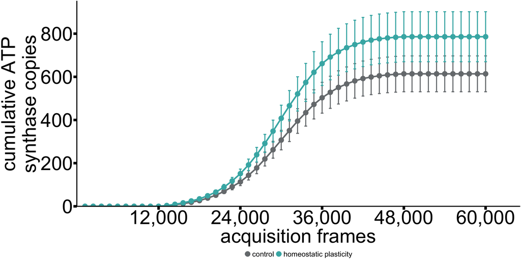

```r
set.seed(20261109)
figs9b_plot <- ggplot(atp_summary, aes(Frames, mean, color = Condition, group = Condition)) +
  geom_errorbar(aes(ymin = mean - SEM, ymax = mean + SEM), width = 400, linewidth = 2) +
  geom_line(linewidth = 3) +
  geom_point(size = 10) +
  scale_color_manual(labels=c(Control="control",TTX="homeostatic plasticity"), values = c(Control = "#777B7E", TTX = "#42B3B2")) +
  scale_x_continuous(oob = scales::oob_keep, breaks = c(12000, 24000, 36000, 48000, 60000),
                     labels = scales::label_comma(),
                     limits = c(0, 65000), expand = c(0, 0)) +
  scale_y_continuous(oob = scales::oob_keep, breaks = c(0, 200, 400, 600, 800),
                     limits = c(0, 950), expand = c(0, 0),
                     labels = scales::label_comma()) +
  labs(x = "acquisition frames", y = "cumulative ATP\nsynthase copies") +
  theme_classic() +
  theme(axis.title = element_text(size = 80, color = "black"),
        axis.text = element_text(size = 80, color = "black"),
        axis.ticks = element_line(linewidth = 5, color = "black"),
        axis.ticks.length = grid::unit(0.5, "cm"),
        axis.line = element_line(linewidth = 2, color = "black"),
        legend.position = "bottom", legend.text = element_text(size=30), legend.title = element_blank())
figs9b_plot
```

# Fig S9C

MIC60 localization precision estimated by nearest-neighbor analysis (NeNA).

**Source data**  
`Fig S9C, D.csv`

**Columns**

- `Date` — Experiment date
- `Condition` — Control or TTX
- `Dish` — Culture dish ID
- `Cell` — Cell ID
- `Probe` — DNA-PAINT probe (probe00, ATP synthase; probe01, MIC60)
- `NeNA_nm` — Nearest-neighbor localization precision (nm)

## Data

```r
suppressPackageStartupMessages({
  library(dplyr); library(readr); library(ggplot2); library(ggbeeswarm)
})

spacing_map <- c(Control = 1, TTX = 2.2)

nena_mic60 <- read_csv("./Fig S9C, D.csv", show_col_types = FALSE) %>%
  transmute(
    Date = trimws(as.character(Date)),
    Condition = trimws(as.character(Condition)),
    Dish = as.integer(parse_number(as.character(Dish))),
    Cell = as.integer(parse_number(as.character(Cell))),
    Probe = case_when(
      tolower(trimws(Probe)) == "probe00" ~ "ATP synthase",
      tolower(trimws(Probe)) == "probe01" ~ "Mic60",
      TRUE ~ trimws(Probe)
    ),
    NeNA_nm = as.numeric(NeNA_nm)
  ) %>%
  filter(Probe == "Mic60", Condition %in% names(spacing_map),
         Date != "", is.finite(NeNA_nm)) %>%
  mutate(
    Condition = factor(Condition, levels = names(spacing_map)),
    Date = factor(Date),
    x_pos = unname(spacing_map[as.character(Condition)]),
    Condition_Date = paste(Condition, Date, sep = "_")
  )

if (nrow(nena_mic60) == 0) stop("No valid Mic60 measurements remain.")

nena_mic60 %>%
  select(Date, Condition, Dish, Cell, Probe, NeNA_nm) %>%
  mutate(NeNA_nm = round(NeNA_nm, 3))
```

| Date | Condition | Dish | Cell | Probe | NeNA_nm |
| --- | --- | --- | --- | --- | --- |
| 2026-01-08 | Control | 1 | 1 | Mic60 | 17.912 |
| 2026-01-08 | Control | 1 | 2 | Mic60 | 19.606 |
| 2026-01-08 | Control | 1 | 3 | Mic60 | 17.177 |
| 2026-01-08 | Control | 1 | 4 | Mic60 | 15.717 |
| 2026-01-08 | Control | 1 | 6 | Mic60 | 17.409 |
| 2026-01-08 | Control | 1 | 7 | Mic60 | 16.698 |
| 2026-01-08 | Control | 1 | 8 | Mic60 | 18.579 |
| 2026-01-08 | TTX | 1 | 1 | Mic60 | 18.031 |
| 2026-01-08 | TTX | 1 | 2 | Mic60 | 17.286 |
| 2026-01-08 | TTX | 1 | 3 | Mic60 | 18.172 |

[output cut: 35 more lines]

## Summary

```r
summary_table <- nena_mic60 %>%
  group_by(Condition) %>%
  summarise(
    n_Measurements = n(),
    n_Cells = n_distinct(Date, Dish, Cell),
    n_Experiment_Dates = n_distinct(Date),
    `Mean (SE)` = sprintf("%.3f (%.3f)", mean(NeNA_nm),
                          sd(NeNA_nm) / sqrt(n())),
    .groups = "drop"
  )

summary_table
```

| Condition | n_Measurements | n_Cells | n_Experiment_Dates | Mean (SE) |
| --- | --- | --- | --- | --- |
| Control | 23 | 23 | 3 | 20.130 (0.631) |
| TTX | 22 | 22 | 3 | 19.279 (0.577) |

## Statistics

Descriptive analysis.

## Plot

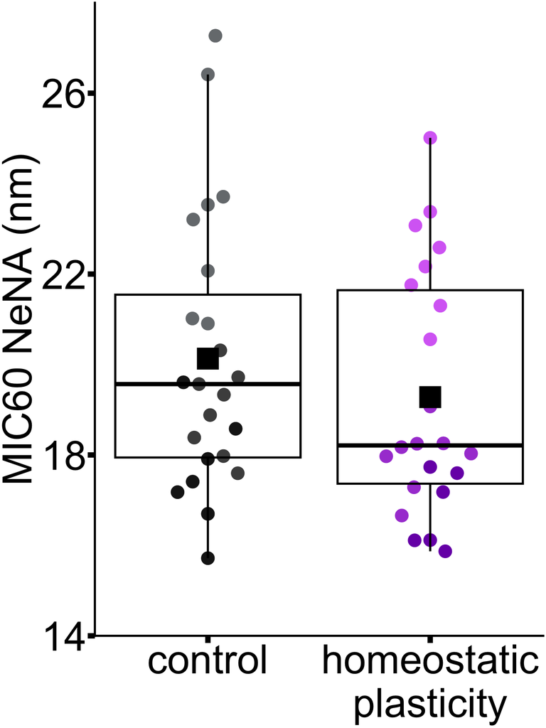

```r
set.seed(20261109)
date_levels <- levels(nena_mic60$Date)
date_colors <- c(
  setNames(
    rep(c("#1A1A1A", "#4D4D4D", "#777B7E"), length.out = length(date_levels)),
    paste("Control", date_levels, sep = "_")
  ),
  setNames(
    rep(c("#A949D5", "#7A20B5", "#D871F5"), length.out = length(date_levels)),
    paste("TTX", date_levels, sep = "_")
  )
)

figs9c_plot <- ggplot(nena_mic60, aes(x_pos, NeNA_nm, color = Condition_Date)) +
  ggbeeswarm::geom_beeswarm(
    cex = 7, priority = "random", size = 12, corral = "random"
  ) +
  geom_boxplot(
    aes(group = x_pos), fill = NA, width = 1, linewidth = 2,
    outlier.shape = NA, color = "black"
  ) +
  stat_summary(
    aes(group = x_pos), fun = mean, geom = "point",
    shape = 15, size = 20, color = "black"
  ) +
  scale_x_continuous(
    breaks = unname(spacing_map),
    labels = c("control", "homeostatic\nplasticity")
  ) +
  scale_y_continuous(oob = scales::oob_keep,
    breaks = c(14, 18, 22, 26),
    limits = c(14, 28),
    expand = c(0, 0)
  ) +
  scale_color_manual(values = date_colors) +
  labs(x = NULL, y = "MIC60 NeNA (nm)") +
  theme_classic() +
  theme(
    axis.title = element_text(size = 80, color = "black"),
    axis.text = element_text(size = 80, color = "black"),
    axis.ticks = element_line(linewidth = 5, color = "black"),
    axis.ticks.length = grid::unit(0.5, "cm"),
    axis.line = element_line(linewidth = 2, color = "black"),
    legend.position = "none"
  )

figs9c_plot
```

# Fig S9D

ATP synthase localization precision estimated by nearest-neighbor analysis (NeNA).

**Source data**  
`Fig S9C, D.csv`

**Columns**

- `Date` — Experiment date
- `Condition` — Control or TTX
- `Dish` — Culture dish ID
- `Cell` — Cell ID
- `Probe` — DNA-PAINT probe (probe00, ATP synthase; probe01, MIC60)
- `NeNA_nm` — Nearest-neighbor localization precision (nm)

## Data

```r
suppressPackageStartupMessages({
  library(dplyr); library(readr); library(ggplot2); library(ggbeeswarm)
})

spacing_map <- c(Control = 1, TTX = 2.2)

nena_atp <- read_csv("./Fig S9C, D.csv", show_col_types = FALSE) %>%
  transmute(
    Date = trimws(as.character(Date)),
    Condition = trimws(as.character(Condition)),
    Dish = as.integer(parse_number(as.character(Dish))),
    Cell = as.integer(parse_number(as.character(Cell))),
    Probe = case_when(
      tolower(trimws(Probe)) == "probe00" ~ "ATP synthase",
      tolower(trimws(Probe)) == "probe01" ~ "Mic60",
      TRUE ~ trimws(Probe)
    ),
    NeNA_nm = as.numeric(NeNA_nm)
  ) %>%
  filter(Probe == "ATP synthase", Condition %in% names(spacing_map),
         Date != "", is.finite(NeNA_nm)) %>%
  mutate(
    Condition = factor(Condition, levels = names(spacing_map)),
    Date = factor(Date),
    x_pos = unname(spacing_map[as.character(Condition)]),
    Condition_Date = paste(Condition, Date, sep = "_")
  )

if (nrow(nena_atp) == 0) stop("No valid ATP synthase measurements remain.")

nena_atp %>%
  select(Date, Condition, Dish, Cell, Probe, NeNA_nm) %>%
  mutate(NeNA_nm = round(NeNA_nm, 3))
```

| Date | Condition | Dish | Cell | Probe | NeNA_nm |
| --- | --- | --- | --- | --- | --- |
| 2026-01-08 | Control | 1 | 1 | ATP synthase | 11.229 |
| 2026-01-08 | Control | 1 | 2 | ATP synthase | 12.535 |
| 2026-01-08 | Control | 1 | 3 | ATP synthase | 11.635 |
| 2026-01-08 | Control | 1 | 4 | ATP synthase | 11.370 |
| 2026-01-08 | Control | 1 | 6 | ATP synthase | 11.255 |
| 2026-01-08 | Control | 1 | 7 | ATP synthase | 12.214 |
| 2026-01-08 | Control | 1 | 8 | ATP synthase | 11.756 |
| 2026-01-08 | TTX | 1 | 1 | ATP synthase | 11.854 |
| 2026-01-08 | TTX | 1 | 2 | ATP synthase | 11.615 |
| 2026-01-08 | TTX | 1 | 3 | ATP synthase | 12.329 |

[output cut: 35 more lines]

## Summary

```r
summary_table <- nena_atp %>%
  group_by(Condition) %>%
  summarise(
    n_Measurements = n(),
    n_Cells = n_distinct(Date, Dish, Cell),
    n_Experiment_Dates = n_distinct(Date),
    `Mean (SE)` = sprintf("%.3f (%.3f)", mean(NeNA_nm),
                          sd(NeNA_nm) / sqrt(n())),
    .groups = "drop"
  )

summary_table
```

| Condition | n_Measurements | n_Cells | n_Experiment_Dates | Mean (SE) |
| --- | --- | --- | --- | --- |
| Control | 23 | 23 | 3 | 12.837 (0.260) |
| TTX | 22 | 22 | 3 | 12.641 (0.220) |

## Statistics

Descriptive analysis.

## Plot

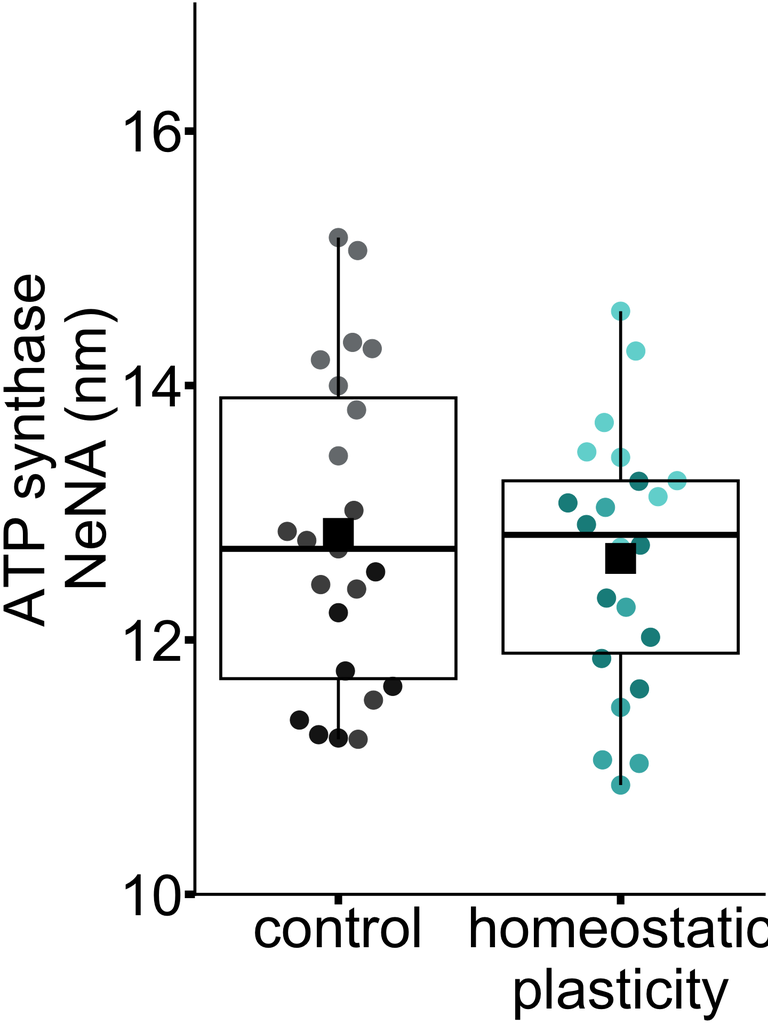

```r
set.seed(20261109)
date_levels <- levels(nena_atp$Date)
date_colors <- c(
  setNames(
    rep(c("#1A1A1A", "#4D4D4D", "#777B7E"), length.out = length(date_levels)),
    paste("Control", date_levels, sep = "_")
  ),
  setNames(
    rep(c("#168C8B", "#42B3B2", "#70D6D4"), length.out = length(date_levels)),
    paste("TTX", date_levels, sep = "_")
  )
)

figs9d_plot <- ggplot(nena_atp, aes(x_pos, NeNA_nm, color = Condition_Date)) +
  ggbeeswarm::geom_beeswarm(
    cex = 7, priority = "random", size = 12, corral = "random"
  ) +
  geom_boxplot(
    aes(group = x_pos), fill = NA, width = 1, linewidth = 2,
    outlier.shape = NA, color = "black"
  ) +
  stat_summary(
    aes(group = x_pos), fun = mean, geom = "point",
    shape = 15, size = 20, color = "black"
  ) +
  scale_x_continuous(
    breaks = unname(spacing_map),
    labels = c("control", "homeostatic\nplasticity")
  ) +
  scale_y_continuous(oob = scales::oob_keep,
    breaks = c(10, 12, 14, 16),
    limits = c(10, 17),
    expand = c(0, 0)
  ) +
  scale_color_manual(values = date_colors) +
  labs(x = NULL, y = "ATP synthase\nNeNA (nm)") +
  theme_classic() +
  theme(
    axis.title = element_text(size = 80, color = "black"),
    axis.text = element_text(size = 80, color = "black"),
    axis.ticks = element_line(linewidth = 5, color = "black"),
    axis.ticks.length = grid::unit(0.5, "cm"),
    axis.line = element_line(linewidth = 2, color = "black"),
    legend.position = "none"
  )

figs9d_plot
```

# Fig S9E

Distribution of DNA-PAINT localizations per detected MIC60 copy.

**Source data**  
`Fig S9E, F.csv`

**Columns**

- `Date` — Experiment date
- `Condition` — Control or TTX
- `Dish` — Culture dish ID
- `Cell` — Cell ID
- `cluster_id` — DNA-PAINT cluster ID
- `Mic60_locs` — Localizations per MIC60 cluster

## Data

The histogram shows 1–100 localizations per cluster.

```r
suppressPackageStartupMessages({
  library(dplyr); library(readr); library(tidyr); library(ggplot2)
})

X_LIMITS <- c(8, 102); X_BREAKS <- seq(10, 100, 10)
Y_LIMITS <- c(0, 700); Y_BREAKS <- c(0, 150, 300, 450, 600)

mic60_locs <- read_csv("./Fig S9E, F.csv", show_col_types = FALSE) %>%
  transmute(Date = trimws(as.character(Date)),
            Condition = trimws(as.character(Condition)),
            Dish = as.integer(parse_number(as.character(Dish))),
            Cell = as.integer(parse_number(as.character(Cell))),
            cluster_id, localizations = as.numeric(Mic60_locs)) %>%
  filter(Condition %in% c("Control", "TTX"), Date != "",
         is.finite(localizations), localizations > 0) %>%
  mutate(Condition = factor(Condition, levels = c("Control", "TTX")))

if (any(mic60_locs$localizations < 0))
  stop("Negative Mic60 localization counts were found.")
if (any(abs(mic60_locs$localizations - round(mic60_locs$localizations)) > 1e-6))
  stop("Non-integer Mic60 localization counts were found.")

mic60_locs <- mic60_locs %>% mutate(localizations = round(localizations))

mic60_locs %>%
  transmute(Date, Condition, Dish, Cell, cluster_id,
            Mic60_locs = localizations)
```

| Date | Condition | Dish | Cell | cluster_id | Mic60_locs |
| --- | --- | --- | --- | --- | --- |
| 2026-01-08 | Control | 1 | 1 | 4 | 16 |
| 2026-01-08 | Control | 1 | 1 | 6 | 11 |
| 2026-01-08 | Control | 1 | 1 | 7 | 13 |
| 2026-01-08 | Control | 1 | 1 | 9 | 14 |
| 2026-01-08 | Control | 1 | 1 | 10 | 23 |
| 2026-01-08 | Control | 1 | 1 | 12 | 11 |
| 2026-01-08 | Control | 1 | 1 | 13 | 24 |
| 2026-01-08 | Control | 1 | 1 | 14 | 14 |
| 2026-01-08 | Control | 1 | 1 | 15 | 21 |
| 2026-01-08 | Control | 1 | 1 | 16 | 15 |

[output cut: 9990 more lines]

## Summary

```r
summary_table <- mic60_locs %>%
  group_by(Condition) %>%
  summarise(
    n_Clusters = n(),
    n_Cells = n_distinct(Date, Dish, Cell),
    n_Experiment_Dates = n_distinct(Date),
    `Mean (SE)` = sprintf("%.3f (%.3f)", mean(localizations),
                          sd(localizations) / sqrt(n())),
    `Clusters from 1-100` = sum(localizations <= 100),
    `Clusters above 100` = sum(localizations > 100),
    .groups = "drop"
  )

combined_summary <- mic60_locs %>%
  summarise(
    Probe = "Mic60",
    `Combined mean (SE)` = sprintf("%.3f (%.3f)", mean(localizations),
                                    sd(localizations) / sqrt(n()))
  )

summary_table
```

| Condition | n_Clusters | n_Cells | n_Experiment_Dates | Mean (SE) | Clusters from 1-100 | Clusters above 100 |
| --- | --- | --- | --- | --- | --- | --- |
| Control | 10114 | 23 | 3 | 28.181 (0.209) | 9997 | 117 |
| TTX | 11795 | 22 | 3 | 27.407 (0.193) | 11641 | 154 |

```r
combined_summary
```

| Probe | Combined mean (SE) |
| --- | --- |
| Mic60 | 27.765 (0.142) |

## Statistics

Descriptive analysis.

## Plot

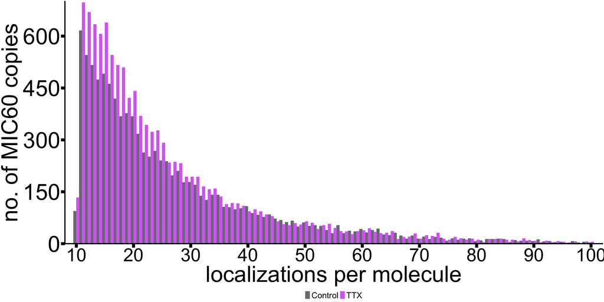

```r
set.seed(20261109)
mic60_histogram <- mic60_locs %>%
  filter(localizations <= 100) %>%
  count(Condition, localizations, name = "n") %>%
  complete(Condition, localizations = 1:100, fill = list(n = 0)) %>%
  mutate(x_pos = if_else(Condition == "Control",
                         localizations - 0.25, localizations + 0.25))

figs9e_plot <- ggplot(mic60_histogram, aes(x_pos, n, fill = Condition, color = Condition)) +
  geom_col(width = 0.5, linewidth = 0.6) +
  scale_fill_manual(values = c(Control = "#777B7E", TTX = "#D871F5")) +
  scale_color_manual(values = c(Control = "#777B7E", TTX = "#D871F5")) +
  scale_x_continuous(oob = scales::oob_keep, breaks = X_BREAKS, limits = X_LIMITS, expand = c(0, 0)) +
  scale_y_continuous(oob = scales::oob_keep, breaks = Y_BREAKS, limits = Y_LIMITS, expand = c(0, 0)) +
  labs(x = "localizations per molecule", y = "no. of MIC60 copies") +
  theme_classic() +
  theme(
    axis.title = element_text(size = 80, color = "black"),
    axis.text.x = element_text(size = 65, color = "black"),
    axis.text.y = element_text(size = 80, color = "black"),
    axis.ticks = element_line(linewidth = 5, color = "black"),
    axis.ticks.length = grid::unit(0.5, "cm"),
    axis.line = element_line(linewidth = 2, color = "black"),
    legend.position = "bottom", legend.text = element_text(size=30), legend.title = element_blank()
  )

figs9e_plot
```

# Fig S9F

Distribution of DNA-PAINT localizations per detected ATP synthase copy.

**Source data**  
`Fig S9E, F.csv`

**Columns**

- `Date` — Experiment date
- `Condition` — Control or TTX
- `Dish` — Culture dish ID
- `Cell` — Cell ID
- `cluster_id` — DNA-PAINT cluster ID
- `ATP_synthase_locs` — Localizations per ATP synthase cluster

## Data

The histogram shows 1–100 localizations per cluster.

```r
suppressPackageStartupMessages({
  library(dplyr); library(readr); library(tidyr); library(ggplot2)
})

X_LIMITS <- c(8, 102); X_BREAKS <- seq(10, 100, 10)
Y_LIMITS <- c(0, 700); Y_BREAKS <- c(0, 150, 300, 450, 600)

atp_locs <- read_csv("./Fig S9E, F.csv", show_col_types = FALSE) %>%
  transmute(Date = trimws(as.character(Date)),
            Condition = trimws(as.character(Condition)),
            Dish = as.integer(parse_number(as.character(Dish))),
            Cell = as.integer(parse_number(as.character(Cell))),
            cluster_id, localizations = as.numeric(ATP_synthase_locs)) %>%
  filter(Condition %in% c("Control", "TTX"), Date != "",
         is.finite(localizations), localizations > 0) %>%
  mutate(Condition = factor(Condition, levels = c("Control", "TTX")))

if (any(atp_locs$localizations < 0))
  stop("Negative ATP synthase localization counts were found.")
if (any(abs(atp_locs$localizations - round(atp_locs$localizations)) > 1e-6))
  stop("Non-integer ATP synthase localization counts were found.")

atp_locs <- atp_locs %>% mutate(localizations = round(localizations))

atp_locs %>%
  transmute(Date, Condition, Dish, Cell, cluster_id,
            ATP_synthase_locs = localizations)
```

| Date | Condition | Dish | Cell | cluster_id | ATP_synthase_locs |
| --- | --- | --- | --- | --- | --- |
| 2026-01-08 | Control | 1 | 1 | 0 | 26 |
| 2026-01-08 | Control | 1 | 1 | 1 | 36 |
| 2026-01-08 | Control | 1 | 1 | 2 | 32 |
| 2026-01-08 | Control | 1 | 1 | 4 | 14 |
| 2026-01-08 | Control | 1 | 1 | 6 | 12 |
| 2026-01-08 | Control | 1 | 1 | 7 | 28 |
| 2026-01-08 | Control | 1 | 1 | 8 | 15 |
| 2026-01-08 | Control | 1 | 1 | 9 | 16 |
| 2026-01-08 | Control | 1 | 1 | 10 | 11 |
| 2026-01-08 | Control | 1 | 1 | 11 | 22 |

[output cut: 9990 more lines]

## Summary

```r
summary_table <- atp_locs %>%
  group_by(Condition) %>%
  summarise(
    n_Clusters = n(),
    n_Cells = n_distinct(Date, Dish, Cell),
    n_Experiment_Dates = n_distinct(Date),
    `Mean (SE)` = sprintf("%.3f (%.3f)", mean(localizations),
                          sd(localizations) / sqrt(n())),
    `Clusters from 1-100` = sum(localizations <= 100),
    `Clusters above 100` = sum(localizations > 100),
    .groups = "drop"
  )

combined_summary <- atp_locs %>%
  summarise(
    Probe = "ATP synthase",
    `Combined mean (SE)` = sprintf("%.3f (%.3f)", mean(localizations),
                                    sd(localizations) / sqrt(n()))
  )

summary_table
```

| Condition | n_Clusters | n_Cells | n_Experiment_Dates | Mean (SE) | Clusters from 1-100 | Clusters above 100 |
| --- | --- | --- | --- | --- | --- | --- |
| Control | 14121 | 23 | 3 | 28.425 (0.154) | 14016 | 105 |
| TTX | 17290 | 22 | 3 | 29.805 (0.138) | 17156 | 134 |

```r
combined_summary
```

| Probe | Combined mean (SE) |
| --- | --- |
| ATP synthase | 29.184 (0.103) |

## Statistics

Descriptive analysis.

## Plot

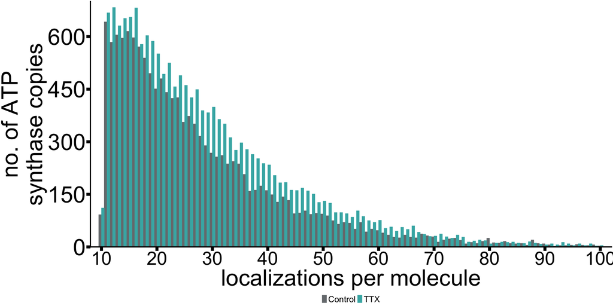

```r
set.seed(20261109)
atp_histogram <- atp_locs %>%
  filter(localizations <= 100) %>%
  count(Condition, localizations, name = "n") %>%
  complete(Condition, localizations = 1:100, fill = list(n = 0)) %>%
  mutate(x_pos = if_else(Condition == "Control",
                         localizations - 0.25, localizations + 0.25))

figs9f_plot <- ggplot(atp_histogram, aes(x_pos, n, fill = Condition, color = Condition)) +
  geom_col(width = 0.5, linewidth = 0.6) +
  scale_fill_manual(values = c(Control = "#777B7E", TTX = "#42B3B2")) +
  scale_color_manual(values = c(Control = "#777B7E", TTX = "#42B3B2")) +
  scale_x_continuous(oob = scales::oob_keep, breaks = X_BREAKS, limits = X_LIMITS, expand = c(0, 0)) +
  scale_y_continuous(oob = scales::oob_keep, breaks = Y_BREAKS, limits = Y_LIMITS, expand = c(0, 0)) +
  labs(x = "localizations per molecule", y = "no. of ATP\nsynthase copies") +
  theme_classic() +
  theme(
    axis.title = element_text(size = 80, color = "black"),
    axis.text.x = element_text(size = 65, color = "black"),
    axis.text.y = element_text(size = 80, color = "black"),
    axis.ticks = element_line(linewidth = 5, color = "black"),
    axis.ticks.length = grid::unit(0.5, "cm"),
    axis.line = element_line(linewidth = 2, color = "black"),
    legend.position = "bottom", legend.text = element_text(size=30), legend.title = element_blank()
  )

figs9f_plot
```

# Fig S9G

MIC60 copy density per whole-mitochondrion area following homeostatic plasticity.

**update for 2026 pending** — The source contains 150 control and 166 treated mitochondria. The v3 legend reports 149 and 165 and describes copies per mitochondrion. The plot uses copies per µm².

**Source data**  
`Fig S9G, H.csv`

**Columns**

- `Date` — Experiment date
- `Condition` — Control or TTX
- `Dish` — Culture dish ID
- `Cell` — Cell ID
- `dendrite` — Dendrite ID
- `mito` — Mitochondrion ID
- `mito_area_um2` — Mitochondrial area (µm²)
- `probe01` — MIC60 copy count

## Data

MIC60 copy density is the copy count divided by mitochondrial area.

```r
suppressPackageStartupMessages({
  library(dplyr); library(readr); library(ggplot2)
  library(ggbeeswarm); library(ggtext)
})

spacing_map <- c(Control = 1, TTX = 2.2)

mic60_mito <- read_csv("./Fig S9G, H.csv", show_col_types = FALSE) %>%
  transmute(
    Date = trimws(as.character(Date)),
    Condition = trimws(as.character(Condition)),
    Dish = as.integer(parse_number(as.character(Dish))),
    Cell = as.integer(parse_number(as.character(Cell))),
    dendrite = as.integer(dendrite),
    mito = as.integer(mito),
    mito_area_um2 = as.numeric(mito_area_um2),
    MIC60_copies = as.numeric(probe01)
  ) %>%
  filter(
    Condition %in% names(spacing_map), Date != "",
    is.finite(mito_area_um2), mito_area_um2 > 0,

    is.finite(MIC60_copies)
  ) %>%
  mutate(
    MIC60_copies_per_mito_um2 = MIC60_copies / mito_area_um2,
    Condition = factor(Condition, levels = names(spacing_map)),
    Date = factor(Date),
    x_pos = unname(spacing_map[as.character(Condition)]),
    Condition_Date = paste(Condition, Date, sep = "_")
  )

if (nrow(mic60_mito) == 0) stop("No valid MIC60 measurements remain.")

mic60_mito %>%
  select(Date, Condition, Dish, Cell, dendrite, mito, mito_area_um2,
         MIC60_copies, MIC60_copies_per_mito_um2) %>%
  mutate(across(where(is.numeric), ~ round(.x, 3)))
```

| Date | Condition | Dish | Cell | dendrite | mito | mito_area_um2 | MIC60_copies | MIC60_copies_per_mito_um2 |
| --- | --- | --- | --- | --- | --- | --- | --- | --- |
| 2026-01-08 | Control | 1 | 1 | 1 | 1 | 1.118 | 15 | 13.416 |
| 2026-01-08 | Control | 1 | 1 | 1 | 2 | 1.677 | 19 | 11.329 |
| 2026-01-08 | Control | 1 | 1 | 1 | 3 | 3.412 | 27 | 7.913 |
| 2026-01-08 | Control | 1 | 1 | 1 | 4 | 2.631 | 6 | 2.280 |
| 2026-01-08 | Control | 1 | 1 | 1 | 5 | 7.980 | 26 | 3.258 |
| 2026-01-08 | Control | 1 | 1 | 1 | 6 | 1.079 | 29 | 26.865 |
| 2026-01-08 | Control | 1 | 2 | 1 | 1 | 7.605 | 119 | 15.648 |
| 2026-01-08 | Control | 1 | 2 | 1 | 2 | 1.706 | 29 | 16.999 |
| 2026-01-08 | Control | 1 | 3 | 1 | 2 | 2.805 | 20 | 7.131 |
| 2026-01-08 | Control | 1 | 3 | 1 | 3 | 1.976 | 10 | 5.061 |

[output cut: 306 more lines]

## Summary

```r
summary_table <- mic60_mito %>%
  group_by(Condition) %>%
  summarise(
    n_Mitochondria = n_distinct(Date, Dish, Cell, dendrite, mito),
    n_Dendrites = n_distinct(Date, Dish, Cell, dendrite),
    n_Cells = n_distinct(Date, Dish, Cell),
    n_Experiment_Dates = n_distinct(Date),
    `Mean (SE)` = sprintf(
      "%.3f (%.3f)",
      mean(MIC60_copies_per_mito_um2),
      sd(MIC60_copies_per_mito_um2) / sqrt(n())
    ),
    .groups = "drop"
  )

summary_table
```

| Condition | n_Mitochondria | n_Dendrites | n_Cells | n_Experiment_Dates | Mean (SE) |
| --- | --- | --- | --- | --- | --- |
| Control | 150 | 33 | 23 | 3 | 22.558 (0.780) |
| TTX | 166 | 31 | 22 | 3 | 27.792 (0.920) |

## Statistics

Two-way ANOVA with condition and experiment date (Type I sums of squares), followed by Tukey HSD.

```r
fit_aov <- aov(MIC60_copies_per_mito_um2 ~ Condition * Date, data = mic60_mito)
condition_p <- as.numeric(anova(fit_aov)["Condition", "Pr(>F)"])
posthoc_p <- as.numeric(TukeyHSD(fit_aov, "Condition")$Condition[1, "p adj"])
format_p <- function(p) ifelse(p < 0.0001, "<0.0001", sprintf("%.4f", p))

stats_table <- tibble(
  Test = "Two-way ANOVA with Tukey HSD",
  Comparison = "Control vs TTX",
  `Control mean (SE)` = summary_table$`Mean (SE)`[summary_table$Condition == "Control"],
  `TTX mean (SE)` = summary_table$`Mean (SE)`[summary_table$Condition == "TTX"],
  `Condition p` = format_p(condition_p),
  `Tukey p` = format_p(posthoc_p)
)

stats_table
```

| Test | Comparison | Control mean (SE) | TTX mean (SE) | Condition p | Tukey p |
| --- | --- | --- | --- | --- | --- |
| Two-way ANOVA with Tukey HSD | Control vs TTX | 22.558 (0.780) | 27.792 (0.920) | <0.0001 | <0.0001 |

```r
anova(fit_aov)
```

|  | Df | Sum Sq | Mean Sq | F value | Pr(>F) |
| --- | --- | --- | --- | --- | --- |
| Condition | 1 | 2158.726 | 2158.72593 | 22.499316 | 3.212089e-06 |
| Date | 2 | 5580.777 | 2790.38838 | 29.082817 | 2.656802e-12 |
| Condition:Date | 2 | 1455.366 | 727.68312 | 7.584276 | 6.084703e-04 |
| Residuals | 310 | 29743.350 | 95.94629 | NA | NA |

## Plot

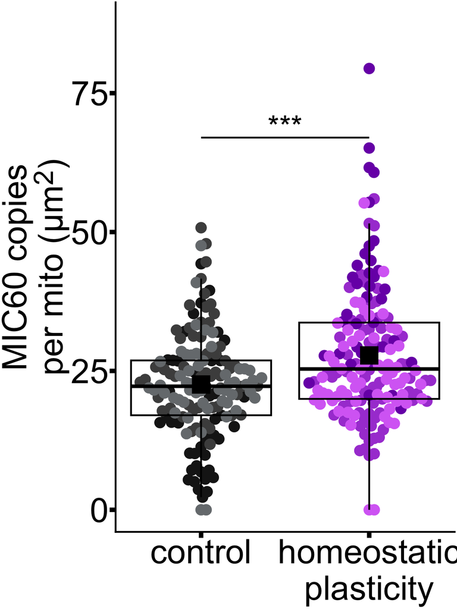

```r
set.seed(20261109)
date_levels <- levels(mic60_mito$Date)
date_colors <- c(
  setNames(rep(c("#1A1A1A", "#4D4D4D", "#777B7E"), length.out = length(date_levels)), paste("Control", date_levels, sep = "_")),
  setNames(rep(c("#A949D5", "#7A20B5", "#D871F5"), length.out = length(date_levels)), paste("TTX", date_levels, sep = "_"))
)

stars <- case_when(posthoc_p < 0.001 ~ "***", posthoc_p < 0.01 ~ "**",
                   posthoc_p < 0.05 ~ "*", TRUE ~ "ns")
plot_stats <- tibble(x1 = 1, x2 = 2.2, y = 67, stars) %>%
  filter(stars != "ns")

figs9g_plot <- ggplot(mic60_mito, aes(x_pos, MIC60_copies_per_mito_um2, color = Condition_Date)) +
  ggbeeswarm::geom_beeswarm(cex = 3, priority = "random", size = 12, corral = "random") +
  geom_boxplot(aes(group = x_pos), fill = NA, width = 1, linewidth = 2,
               outlier.shape = NA, color = "black") +
  stat_summary(aes(group = x_pos), fun = mean, geom = "point",
               shape = 15, size = 20, color = "black") +
  geom_segment(data = plot_stats, aes(x = x1, xend = x2, y = y, yend = y),
               inherit.aes = FALSE, linewidth = 2, color = "black") +
  geom_text(data = plot_stats, aes(x = (x1 + x2) / 2, y = y + 2, label = stars),
            inherit.aes = FALSE, size = 25, color = "black") +
  scale_x_continuous(breaks = unname(spacing_map),
                     labels = c("control", "homeostatic\nplasticity")) +
  scale_y_continuous(expand = expansion(mult = c(0.05, 0.15))) +
  scale_color_manual(values = date_colors) +
  labs(x = NULL, y = "MIC60 copies<br>per mito (&micro;m<sup>2</sup>)") +
  theme_classic() +
  theme(axis.title.x = element_text(size = 80, color = "black"),
        axis.title.y = ggtext::element_markdown(size = 80, color = "black"),
        axis.text = element_text(size = 80, color = "black"),
        axis.ticks = element_line(linewidth = 5, color = "black"),
        axis.ticks.length = grid::unit(0.5, "cm"),
        axis.line = element_line(linewidth = 2, color = "black"),
        legend.position = "none")

figs9g_plot
```

# Fig S9H

ATP synthase copy density per whole-mitochondrion area following homeostatic plasticity.

**update for 2026 pending** — The source contains 150 control and 166 treated mitochondria. The v3 legend reports 149 and 165 and describes copies per mitochondrion. The plot uses copies per µm².

**Source data**  
`Fig S9G, H.csv`

**Columns**

- `Date` — Experiment date
- `Condition` — Control or TTX
- `Dish` — Culture dish ID
- `Cell` — Cell ID
- `dendrite` — Dendrite ID
- `mito` — Mitochondrion ID
- `mito_area_um2` — Mitochondrial area (µm²)
- `probe00` — ATP synthase copy count

## Data

ATP synthase copy density is the copy count divided by mitochondrial area.

```r
suppressPackageStartupMessages({
  library(dplyr); library(readr); library(ggplot2)
  library(ggbeeswarm); library(ggtext)
})

spacing_map <- c(Control = 1, TTX = 2.2)

atp_mito <- read_csv("./Fig S9G, H.csv", show_col_types = FALSE) %>%
  transmute(
    Date = trimws(as.character(Date)),
    Condition = trimws(as.character(Condition)),
    Dish = as.integer(parse_number(as.character(Dish))),
    Cell = as.integer(parse_number(as.character(Cell))),
    dendrite = as.integer(dendrite),
    mito = as.integer(mito),
    mito_area_um2 = as.numeric(mito_area_um2),
    ATP_synthase_copies = as.numeric(probe00)
  ) %>%
  filter(
    Condition %in% names(spacing_map), Date != "",
    is.finite(mito_area_um2), mito_area_um2 > 0,

    is.finite(ATP_synthase_copies)
  ) %>%
  mutate(
    ATP_synthase_copies_per_mito_um2 = ATP_synthase_copies / mito_area_um2,
    Condition = factor(Condition, levels = names(spacing_map)),
    Date = factor(Date),
    x_pos = unname(spacing_map[as.character(Condition)]),
    Condition_Date = paste(Condition, Date, sep = "_")
  )

if (nrow(atp_mito) == 0) stop("No valid ATP synthase measurements remain.")

atp_mito %>%
  select(Date, Condition, Dish, Cell, dendrite, mito, mito_area_um2,
         ATP_synthase_copies, ATP_synthase_copies_per_mito_um2) %>%
  mutate(across(where(is.numeric), ~ round(.x, 3)))
```

| Date | Condition | Dish | Cell | dendrite | mito | mito_area_um2 | ATP_synthase_copies | ATP_synthase_copies_per_mito_um2 |
| --- | --- | --- | --- | --- | --- | --- | --- | --- |
| 2026-01-08 | Control | 1 | 1 | 1 | 1 | 1.118 | 59 | 52.771 |
| 2026-01-08 | Control | 1 | 1 | 1 | 2 | 1.677 | 58 | 34.584 |
| 2026-01-08 | Control | 1 | 1 | 1 | 3 | 3.412 | 170 | 49.825 |
| 2026-01-08 | Control | 1 | 1 | 1 | 4 | 2.631 | 94 | 35.725 |
| 2026-01-08 | Control | 1 | 1 | 1 | 5 | 7.980 | 338 | 42.353 |
| 2026-01-08 | Control | 1 | 1 | 1 | 6 | 1.079 | 48 | 44.466 |
| 2026-01-08 | Control | 1 | 2 | 1 | 1 | 7.605 | 457 | 60.095 |
| 2026-01-08 | Control | 1 | 2 | 1 | 2 | 1.706 | 101 | 59.204 |
| 2026-01-08 | Control | 1 | 3 | 1 | 2 | 2.805 | 106 | 37.793 |
| 2026-01-08 | Control | 1 | 3 | 1 | 3 | 1.976 | 57 | 28.848 |

[output cut: 306 more lines]

## Summary

```r
summary_table <- atp_mito %>%
  group_by(Condition) %>%
  summarise(
    n_Mitochondria = n_distinct(Date, Dish, Cell, dendrite, mito),
    n_Dendrites = n_distinct(Date, Dish, Cell, dendrite),
    n_Cells = n_distinct(Date, Dish, Cell),
    n_Experiment_Dates = n_distinct(Date),
    `Mean (SE)` = sprintf(
      "%.3f (%.3f)",
      mean(ATP_synthase_copies_per_mito_um2),
      sd(ATP_synthase_copies_per_mito_um2) / sqrt(n())
    ),
    .groups = "drop"
  )

summary_table
```

| Condition | n_Mitochondria | n_Dendrites | n_Cells | n_Experiment_Dates | Mean (SE) |
| --- | --- | --- | --- | --- | --- |
| Control | 150 | 33 | 23 | 3 | 30.632 (1.571) |
| TTX | 166 | 31 | 22 | 3 | 42.194 (1.737) |

## Statistics

Two-way ANOVA with condition and experiment date (Type I sums of squares), followed by Tukey HSD.

```r
fit_aov <- aov(ATP_synthase_copies_per_mito_um2 ~ Condition * Date, data = atp_mito)
condition_p <- as.numeric(anova(fit_aov)["Condition", "Pr(>F)"])
posthoc_p <- as.numeric(TukeyHSD(fit_aov, "Condition")$Condition[1, "p adj"])
format_p <- function(p) ifelse(p < 0.0001, "<0.0001", sprintf("%.4f", p))

stats_table <- tibble(
  Test = "Two-way ANOVA with Tukey HSD",
  Comparison = "Control vs TTX",
  `Control mean (SE)` = summary_table$`Mean (SE)`[summary_table$Condition == "Control"],
  `TTX mean (SE)` = summary_table$`Mean (SE)`[summary_table$Condition == "TTX"],
  `Condition p` = format_p(condition_p),
  `Tukey p` = format_p(posthoc_p)
)

stats_table
```

| Test | Comparison | Control mean (SE) | TTX mean (SE) | Condition p | Tukey p |
| --- | --- | --- | --- | --- | --- |
| Two-way ANOVA with Tukey HSD | Control vs TTX | 30.632 (1.571) | 42.194 (1.737) | <0.0001 | <0.0001 |

```r
anova(fit_aov)
```

|  | Df | Sum Sq | Mean Sq | F value | Pr(>F) |
| --- | --- | --- | --- | --- | --- |
| Condition | 1 | 10533.474 | 10533.4735 | 57.277488 | 4.356371e-13 |
| Date | 2 | 78826.032 | 39413.0161 | 214.314731 | 3.588686e-59 |
| Condition:Date | 2 | 1977.326 | 988.6628 | 5.376016 | 5.067609e-03 |
| Residuals | 310 | 57009.777 | 183.9025 | NA | NA |

## Plot

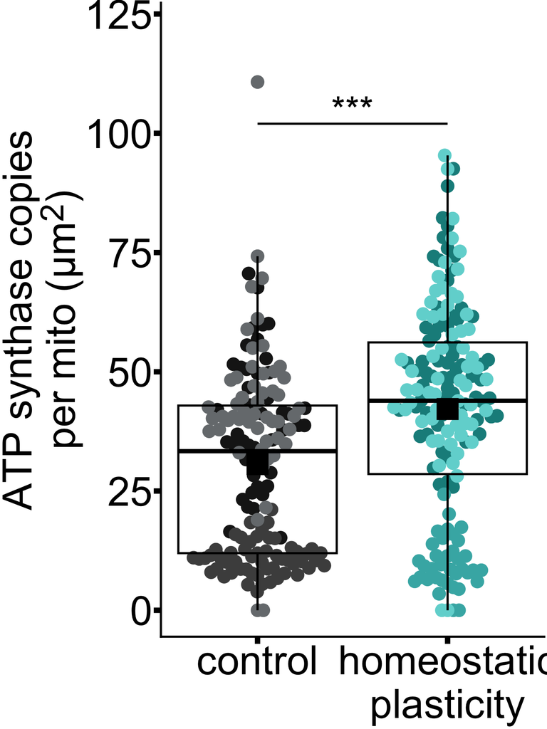

```r
set.seed(20261109)
date_levels <- levels(atp_mito$Date)
date_colors <- c(
  setNames(rep(c("#1A1A1A", "#4D4D4D", "#777B7E"), length.out = length(date_levels)), paste("Control", date_levels, sep = "_")),
  setNames(rep(c("#168C8B", "#42B3B2", "#70D6D4"), length.out = length(date_levels)), paste("TTX", date_levels, sep = "_"))
)

stars <- case_when(posthoc_p < 0.001 ~ "***", posthoc_p < 0.01 ~ "**",
                   posthoc_p < 0.05 ~ "*", TRUE ~ "ns")
plot_stats <- tibble(x1 = 1, x2 = 2.2, y = 102, stars) %>%
  filter(stars != "ns")

figs9h_plot <- ggplot(atp_mito, aes(x_pos, ATP_synthase_copies_per_mito_um2, color = Condition_Date)) +
  ggbeeswarm::geom_beeswarm(cex = 3, priority = "random", size = 12, corral = "random") +
  geom_boxplot(aes(group = x_pos), fill = NA, width = 1, linewidth = 2,
               outlier.shape = NA, color = "black") +
  stat_summary(aes(group = x_pos), fun = mean, geom = "point",
               shape = 15, size = 20, color = "black") +
  geom_segment(data = plot_stats, aes(x = x1, xend = x2, y = y, yend = y),
               inherit.aes = FALSE, linewidth = 2, color = "black") +
  geom_text(data = plot_stats, aes(x = (x1 + x2) / 2, y = y + 3, label = stars),
            inherit.aes = FALSE, size = 25, color = "black") +
  scale_x_continuous(breaks = unname(spacing_map),
                     labels = c("control", "homeostatic\nplasticity")) +
  scale_y_continuous(expand = expansion(mult = c(0.05, 0.15))) +
  scale_color_manual(values = date_colors) +
  labs(x = NULL, y = "ATP synthase copies<br>per mito (&micro;m<sup>2</sup>)") +
  theme_classic() +
  theme(axis.title.x = element_text(size = 80, color = "black"),
        axis.title.y = ggtext::element_markdown(size = 80, color = "black"),
        axis.text = element_text(size = 80, color = "black"),
        axis.ticks = element_line(linewidth = 5, color = "black"),
        axis.ticks.length = grid::unit(0.5, "cm"),
        axis.line = element_line(linewidth = 2, color = "black"),
        legend.position = "none")

figs9h_plot
```